# Pesquisa Literária com R: Metodologia com Quanteda tomando como exemplo o Livro do Desassossego

Diego Giménez e Andressa Gomide

Códigos utilizados para as análises em Pesquisa Literária com R: Análise Quantitativa de Dados Textuais, Quanteda tomando como exemplo o Livro do Desassossego (Giménez e Gomide 2022).

## 1 Ferramentas e preparação dos dados

### 1.1 Instalação

[Quanteda](https://quanteda.io/) (Quantitative Analysis of Textual Data) é um pacote de R para a manipulação e análise de dados textuais.

A instalação do R varia de acordo com o sistema operacional (ex.: Windows, Mac, Linux) bem como suas diferentes versões. Há várias fontes onde se pode obter instruções atualizadas de como instalar o R (e.x.https://didatica.tech/como-instalar-a-linguagem-r-e-o-rstudio/). O Comprehensive R Archive Network [(CRAN)](https://cran.r-project.org/), a rede oficial de distribuição do R, oferece instruções confiáveis para tal, porém, talvez não tão detalhada como em outras fontes.

Uma outra sugestão é instalar uma interface gráfica do utilizador, do inglês Graphical User Interface (GUI). As GUIs facilitam consideravelmente a interação do usuário com o computador. O [(RStudio)](https://www.rstudio.com/) é a GUI mais utilizada para R, e, assim como o R, é gratuita e possui o código aberto.

### 1.2 Configuração: preparando o ambiente.

Ao reutilizar códigos, é uma boa prática estar atento à versão instalada tanto do R quanto das bibliotecas utilizadas. Não é necessário que as versões sejam as mesmas daquelas utilizadas durante a criação dos códigos, entretanto, em alguns casos, pode não haver compatibilidade entre versões diferentes e algumas funções ou pacotes podem ter sido descontinuados. Este artigo foi escrito utilizando a versão 4.2.0 do R. Para nossa análise, utilizaremos alguns pacotes já existentes. Estes pacotes nada mais são que extensões para o R que normalmente contém dados ou códigos. Para utilizá-los, precisamos instalá-los no computador, caso ainda não tenha sido feito, e carregá-lo ao R. Uma vantagem de carregar apenas os pacotes necessários (em vez de todos os pacotes instalados) é evitar processamento computacional desnecessário. O código abaixo cria uma lista dos pacotes utilizados na presente análise e os carrega, instalando os que ainda não estavam presentes.

```r
# verificar a versão do R
R.version.string
```

```
## [1] "R version 4.2.0 (2022-04-22 ucrt)"
```

Para nossa análise, utilizaremos alguns pacotes já existentes. Estes pacotes nada mais são que extensões para o R que normalmente contém dados ou códigos. Para utilizá-los, precisamos instalá-los no computador, caso ainda não tenha sido feito, e carregá-lo ao R. Uma vantagem de carregar apenas os pacotes necessários (ao invés de todos os pacotes instalados) é evitar processamento computacional desnecessário. O código abaixo cria uma lista dos pacotes utilizados na presente análise e os carrega, instalando os que ainda não estavam presentes.

```r
# Listamos os pacotes que precisamos
packages = c("quanteda", "quanteda.textmodels", "quanteda.textstats", "quanteda.textplots",
             "newsmap", # para classificar documentos, com base em “seed words”
             "readtext", # para ler diferentes formatos de texto
             "spacyr", # para anotação de classes gramaticais, reconhecimento de entidades e anotação sintática (python deve estar instalado)
             "ggplot2", #para gráfico simples das frequências
             "seededlda", # para modelagem de tópico
             "stringr" # para as expressões regulares
             )

# Instalamos (se necessário) e carregamos os pacotes
package.check <- lapply(
  packages,
  FUN = function(x) {
    if (!require(x, character.only = TRUE)) {
      install.packages(x, dependencies = TRUE)
      require(x, character.only = TRUE)
    }
  }
)
```

Os códigos abaixo foram implementados na versão 3.2.1 do Quanteda. Utilizar uma versão diferente dessa pode resultar em erros ou resultados indesejados. Para verificar qual é a versão dos pacotes, empregamos a função `packageVersion`. Para verificar a versão do R, utilizamos `R.version.string`.

```r
# verificar versão do quanteada
packageVersion("quanteda")
```

```
## [1] '3.2.1'
```

Por fim, precisamos estabelecer qual será nosso diretório de trabalho. Este será o local onde os resultados serão salvos. Para identificar qual é o diretório de trabalho selecionado, utilizamos `getwd()`. Esta função retorna o caminho absoluto, i.e., o endereço completo, do diretório. Para definirmos o novo local de trabalho, utilizamos a função `setwd()`. Arquivos salvos nesse diretório podem ser lidos apenas com a indicação do nome do arquivo. Isto porque podemos utilizar o caminho relativo, ou seja, o endereço onde o arquivo está salvo a partir do diretório em que estamos trabalhando.

### 1.3 Dados

Uma vez instalados os pacotes necessários, pode-se proceder à análise do corpus. Para isso, precisamos carregar o corpus no R. Se estamos trabalhando com dados armazenados localmente, isto é, disponíveis no computador onde as análises serão realizadas, basta utilizar a função `readtext()`, indicando o local (relativo ou absoluto) do arquivo desejado.

O livro pode ser lido como um arquivo único,

```r
# para lermos um arquivo único com todo o conteúdo do livro
ldod_unico <- readtext("corpora/pessoa_ldod_completo.txt", encoding = "latin1")

# retorna a estrutura do objeto criado
str(ldod_unico)
```

```
## Classes 'readtext' and 'data.frame': 1 obs. of  2 variables:
##  $ doc_id: chr "pessoa_ldod_completo.txt"
##  $ text  : chr "Na casa de Saude de Cascaes\n\nInclue: -(1) Introdução, entrevista com António Mora.\n\t (2) Alberto Caeiro.\n\"| __truncated__
```

ou considerando cada fragmento do livro como uma unidade:

```r
# ler todos os arquivos na pasta ldod do diretório corpora
ldod_files <- readtext("corpora/ldod", encoding = "utf-8")

# retornar a estrutura do objeto criado
str(ldod_files)
```

```
## Classes 'readtext' and 'data.frame': 518 obs. of  2 variables:
##  $ doc_id: chr  "001_Na casa de Saude de Cascaes.txt" "002_Peristylo.txt" "003_Introducção.txt" "004_Na Floresta do....txt" ...
##  $ text  : chr  "Na casa de Saude de Cascaes\n\nInclue: -(1) Introdu" "L.doD.\n\n1. Peristylo.\n2. Bailado.\n3. O ultimo Cysne.\n4. Tecedeira...\n5. Encantamento.\n6. Apotheose do Ab"| __truncated__ "L.doD.\n\n1. Introduc" "L.doD.\n\n1- Na Floresta do Alheamento.\n2- Viagem nunca feita.\n3. Inter…
```

Os textos acima derivam da edição de Jacinto do Prado Coelho (1982) disponível no [arquivo LdoD](https://ldod.uc.pt/edition/acronym/JPC), disponíveis em UTF-8. O arquivo completo foi salvo com a codificação latin1 e informação para-textual e editorial (como notas dos editores) que pudessem interferir na pesquisa automática do software foram eliminadas.

As análises abaixo serão demonstradas utilizando os dois corpora, em diferentes momentos.

### 1.3.1 Limpeza

A limpeza abaixo foi aplicada apenas aos textos salvos separadamente (`ldod_files`). O arquivo com o livro em um único texto (`ldod_unico`) já havia sido limpo anteriormente.

```r
# criamos uma cópia para recuperarmos o orignal caso haja erros na regex
ldod_clean <- ldod_files

## remoção dos elementos indesejados
# remover L.doD. no inicio dos fragmentos
ldod_clean$text <- str_replace_all(ldod_clean$text, "^\t?+L.\\s?+do\\s?+D.", "")

# remover números no início de linhas (index)
ldod_clean$text <- str_replace_all(ldod_clean$text, "\\n\\d", "\n")

# remover datas
ldod_clean$text <- str_replace_all(ldod_clean$text, "\\d{1,2}-(\\d{1,2}|[IVX]{1,4})-19\\d{2}", "")
```

### 1.4 Investigações com o Quanteda

Depois que os arquivos estão carregados no sistema, precisamos criar um objeto “corpus”, i.e., o formato necessário para que o Quanteda possa processar e gerar informações sobre o(s) texto(s). Para isso, basta aplicar a função `corpus`. Automaticamente, o texto é segmentado em tokens e frases. Tokens correspondem a todas as ocorrências (incluindo as repetições) de palavras, e outros itens como pontuação, números e símbolos. Quando investigamos o corpus com a função `summary`, temos a contagem das frases, tokens e dos types (o número de tokens distintos em um corpus).

```r
# criar o corpus de vários arquivos
corpus_clean <- corpus(ldod_clean)
# ver um resumo do corpus
summary(corpus_clean)
```

|  | Text | Types | Tokens | Sentences |
| --- | --- | --- | --- | --- |
| 1 | 001_Na casa de Saude de Cascaes.txt | 12 | 13 | 1 |
| 2 | 002_Peristylo.txt | 17 | 31 | 8 |
| 3 | 003_Introducção.txt | 2 | 2 | 2 |
| 4 | 004_Na Floresta do....txt | 30 | 44 | 8 |
| 5 | 005_Metaphysica do Epitheto.txt | 4 | 4 | 1 |
| 6 | 006_Do Livro do Desasocego.txt | 19 | 23 | 1 |
| 7 | 007_Nota para as edições próprias.txt | 4 | 4 | 1 |
| 8 | 008_A organização do livro deve basear-se numa escolha.txt | 5 | 5 | 1 |
| 9 | 009_2 idéas para o L. do D..txt | 2 | 2 | 1 |
| 10 | 010_Cop. duma carta para Pretória.txt | 7 | 7 | 1 |

[output cut: 90 more lines]

```r
# criar corpus do arquivo único
corpus_unico <- corpus(ldod_unico)
summary(corpus_unico)
```

|  | Text | Types | Tokens | Sentences |
| --- | --- | --- | --- | --- |
| 1 | pessoa_ldod_completo.txt | 17647 | 161186 | 7542 |

Caso seja necessário, podemos alterar a estrutura do nosso corpus. No `corpus_unico`, temos um corpus feito com apenas um texto. Com `corpus_reshape` podemos criar um novo corpus em que cada frase seja considerada um texto, ou seja, uma unidade.

```r
# revelar o número de textos no corpus
ndoc(corpus_unico)
```

```
## [1] 1
```

```r
# remodelar o corpus, tornando cada sentença uma unidade
corpus_sents <- corpus_reshape(corpus_unico, to = "sentences")

# apresentar um resumo do corpus
summary(corpus_sents)
```

|  | Text | Types | Tokens | Sentences |
| --- | --- | --- | --- | --- |
| 1 | pessoa_ldod_completo.txt.1 | 18 | 19 | 1 |
| 2 | pessoa_ldod_completo.txt.2 | 6 | 6 | 1 |
| 3 | pessoa_ldod_completo.txt.3 | 6 | 6 | 1 |
| 4 | pessoa_ldod_completo.txt.4 | 8 | 8 | 1 |
| 5 | pessoa_ldod_completo.txt.5 | 5 | 5 | 1 |
| 6 | pessoa_ldod_completo.txt.6 | 19 | 21 | 1 |
| 7 | pessoa_ldod_completo.txt.7 | 2 | 2 | 1 |
| 8 | pessoa_ldod_completo.txt.8 | 2 | 2 | 1 |
| 9 | pessoa_ldod_completo.txt.9 | 2 | 2 | 1 |
| 10 | pessoa_ldod_completo.txt.10 | 2 | 2 | 1 |

[output cut: 90 more lines]

```r
# número total de unidades na nova formatação do corpus
ndoc(corpus_sents)
```

```
## [1] 7542
```

Os exemplos acima nos mostram que um corpus é um conjunto de textos com informações sobre cada texto (metadados), do qual pode-se extrair facilmente a contagem de tokens, types e frases para cada texto. Porém, para realizar análises quantitativas no corpus, precisamos quebrar os textos em tokens (tokenização). É possível também filtrá-los, removendo elementos como pontuação, símbolos, números, urls e separadores.

```r
# tokenizar nossos três corpora
toks_unico <- tokens(corpus_unico)
toks_sents <- tokens(corpus_sents)
toks_files <- tokens(corpus_clean)


## abaixo filtramos os três corpora de formas diversas,para demonstração
# remover pontuação (corpus limpo com regex)
toks_nopunct_files <- tokens(corpus_clean, remove_punct = TRUE)
toks_nopunct_unico <- tokens(corpus_unico, remove_punct = TRUE)

# remover números (corpus com apenas um arquivo)
toks_nonumbr <- tokens(corpus_unico, remove_numbers = TRUE)

# remover separadores (Unicode "Separator" [Z] and "Control" [C] categories)  (corpus feito por frases)
toks_nosept <- tokens(corpus_sents, remove_separators = TRUE)

# remover vários elementos ao mesmo tempo (corpus com apenas um arquivo)
toks_simples <- tokens(corpus_unico, remove_numbers = TRUE, remove_symbols = TRUE, remove_punct = TRUE)
```

É possível também remover tokens indesejados. Quanteda oferece uma lista de “stopwords” para diferentes línguas. Stopwords, ou palavras vazias em português, são palavras a serem removidas quando se processa textos para análises computacionais. Não existe uma lista padrão, mas geralmente as stopwords são as palavras mais frequentemente utilizadas em uma língua, como preposições e artigos. O bloco abaixo elimina as palavras incluídas na lista stopwords para português e inclui outras palavras que se repetem no corpus em questão.

```r
# eliminar stopwords do corpus feito com um único arquivo
toks_nostop <- tokens_select(toks_unico, pattern = stopwords("pt"), selection = "remove")

# eliminar tokens específicios do corpus feito com vários arquivos e limpo com regex, após eliminação das pontuações
toks_selected_files <- tokens_select(toks_nopunct_files, pattern = c("é", "l.dod", "porqu", "ha", "ond", "tudo", "toda", "porque", "onde", "mim", "todo", "tão", "ter", "grand", "ell", "sobr", stopwords("pt")), selection = "remove")

# eliminar tokens específicios do corpus feito com um arquivo, após eliminação das pontuações
toks_selected_unico <- tokens_select(toks_nopunct_unico, pattern = c("é", "l.dod", "porqu", "ha", "ond", "tudo", "toda", "porque", "onde", "mim", "todo", "tão", "ter", "grand", "ell", "sobr", stopwords("pt")), selection = "remove")
```

Após a tokenização, o próximo passo é criar uma tabela com a frequência de cada token por cada texto, ou nos termos do quanteda, uma document-feature-matrix (dfm). A dfm é um pré-requisito para várias outras funções no quanteada, como é o caso da `topfeatures`, que retorna os tokens mais frequentes e um corpus.

Após a tokenização, o próximo passo é criar uma tabela com a frequência de cada token por cada texto, ou nos termos do Quanteda, um `document-feature-matrix` (dfm). A dfm é um pré-requisito para várias outras funções no quanteda, como é o caso da topfeatures, que retorna os tokens mais frequentes e um corpus.

```r
# aqui podemos ver as 20 palavras mais frequentes quando removemos
# números, símbolos e pontuação
dfm_simples <- dfm(toks_simples)
print("com remoção de número, simbolos e pontuação")
```

```
## [1] "com remoção de número, simbolos e pontuação"
```

```r
topfeatures(dfm_simples, 20)
```

```
##  que   de    a    o    e  não    é   do   da   um   se como  uma   os   em para
## 6147 5118 4743 4181 4104 2547 1932 1846 1797 1692 1563 1328 1317 1284 1265 1142
##  com   as   me  por
## 1054 1020  982  786
```

```r
dfm_nostop <- dfm(toks_nostop)
print("remoção de stopwords")
```

```
## [1] "remoção de stopwords"
```

```r
topfeatures(dfm_nostop, 20)
```

```
##      ,      .      é   vida      ;   tudo      ?    ser porque    mim      /
##  12988   8524   1932    763    650    570    539    534    501    487    441
##   alma      (      )     ha   nada sempre    ter  nunca   onde
##    412    363    362    345    334    331    315    314    301
```

```r
dfm_selected_unico <- dfm(toks_selected_unico)
print("remoção de tokens selecionados no corpus previamente limpo com regex e sem stopwords")
```

```
## [1] "remoção de tokens selecionados no corpus previamente limpo com regex e sem stopwords"
```

```r
topfeatures(dfm_selected_unico, 20)
```

```
##     vida      ser     alma     nada   sempre    nunca    todos   outros
##      763      534      412      334      331      314      290      264
##      sei    sonho    mundo    assim    sobre    ainda qualquer    outro
##      261      250      233      220      215      210      200      198
##    outra   grande      dia    coisa
##      193      184      183      175
```

```r
dfm_selected_files <- dfm(toks_selected_files)
print("remoção de tokens selecionados no corpus de arquivo único e sem stopwords")
```

[output not shown]

```r
topfeatures(dfm_selected_files, 20)
```

```
##        n     vida   sempre    nunca        s    sonho     nada     alma
##       93       51       30       19       18       17       17       16
##    chuva    sensa      ser     hoje      dia    todos     dias        c
##       15       15       15       14       14       14       14       11
##    vezes qualquer   quanto   coisas
##       11       11       11       11
```

Depois de gerar a lista de tokens, podemos então explorar o corpus. Uma das técnicas mais simples e utilizadas para investigação de corpus é através das linhas de concordâncias, ou concordance lines, ou keywords in context (`kwic`). As linhas de concordância mostram fragmentos do corpus onde há ocorrência do(s) termo(s) buscados. O número de palavras no contexto, pode ser estipulado pelo usuário, sendo 5 tokens a esquerda e 5 a direita o padrão. A primeira coluna indica o nome do arquivo onde a palavra buscada ocorre. Há várias opções para buscas. Elas podem ser feitas por palavras ou por fragmentos, sequências, combinações das mesmas.

```r
# ocorrências de palavras que iniciam com “feli”.
kwic(toks_files, pattern =  "feli*")
```

| docname | from | to | pre | keyword | post | pattern |
| --- | --- | --- | --- | --- | --- | --- |
| 023_Omar Khayyam.txt | 10 | 10 | uma personalidade ; eu , | feliz | ou infelizmente , n | feli* |
| 082_Irrita-me a felicidade de todos estes homens.txt | 3 | 3 | Irrita-me a | felicidade | de todos estes homens que | feli* |
| 094_Dobraram a curva do caminho.txt | 23 | 23 | som das suas vozes era | felizes | [ sic ] . Ellas | feli* |
| 222_Tudo se me confunde.txt | 181 | 181 | quando eu era creança e | feliz | , vivia numa casa do | feli* |
| 405_O homem vulgar, por mais dura que lhe seja a vida.txt | 18 | 18 | , tem ao menos a | felicidade | de a n | feli* |

```r
# Podemos também procurar por mais de uma palavra ao mesmo tempo
kwic(toks_files, pattern = c("feli*", "alegr*"))
```

| docname | from | to | pre | keyword | post | pattern |
| --- | --- | --- | --- | --- | --- | --- |
| 023_Omar Khayyam.txt | 10 | 10 | uma personalidade ; eu , | feliz | ou infelizmente , n | feli* |
| 082_Irrita-me a felicidade de todos estes homens.txt | 3 | 3 | Irrita-me a | felicidade | de todos estes homens que | feli* |
| 094_Dobraram a curva do caminho.txt | 23 | 23 | som das suas vozes era | felizes | [ sic ] . Ellas | feli* |
| 222_Tudo se me confunde.txt | 181 | 181 | quando eu era creança e | feliz | , vivia numa casa do | feli* |
| 241_Aquella malicia incerta e quasi imponderavel.txt | 8 | 8 | incerta e quasi imponderavel que | alegra | qualquer cora | alegr* |
| 405_O homem vulgar, por mais dura que lhe seja a vida.txt | 18 | 18 | , tem ao menos a | felicidade | de a n | feli* |

```r
# e por sequência de mais de um token
kwic(toks_files, pattern = phrase("me fal*"))
```

| docname | from | to | pre | keyword | post | pattern |
| --- | --- | --- | --- | --- | --- | --- |
| 225_Na minha alma ignobil e profunda.txt | 288 | 289 | do regaço da rainha que | me falta | , cahe , como um | me fal* |
| 242_Tive um certo talento para a amizade.txt | 17 | 18 | amigos , quer porque elles | me faltassem | , quer porque a amizade | me fal* |

#### 1.4.1 N-gramas

Listas de frequência de palavras podem ser úteis para identificar elementos comuns a um texto. Porém, em muitos casos, é importante também saber em qual contexto estas palavras estão. Identificar quais palavras coocorrem frequentemente em um corpus podem nos revelar ainda mais informações sobre o texto. Por exemplo, saber que o par “estou triste” ocorre frequentemente no corpus nos diz mais sobre o corpus do que a frequência da palavra “triste” sozinha. A sequência “estou triste” é um exemplo de que chamamos de n-grams, ou neste caso específico, bigramas. N-gramas são sequências de duas ou mais palavras que ocorrem em um texto. Para gerar listas de n-grams, partimos de uma lista de tokens e delimitamos o número mínimo e máximo de tokens em cada n-grama.

```r
# criar uma lista de 2-grama, 3-grama e 4-grama
toks_ngram <- tokens_ngrams(toks_simples, n = 2:4)
# visualizar apenas os 30 mais frequentes
head(toks_ngram[[1]], 30)
```

```
##  [1] "Na_casa"               "casa_de"               "de_Saude"
##  [4] "Saude_de"              "de_Cascaes"            "Cascaes_Inclue"
##  [7] "Inclue_Introdução"     "Introdução_entrevista" "entrevista_com"
## [10] "com_António"           "António_Mora"          "Mora_Alberto"
## [13] "Alberto_Caeiro"        "Caeiro_Ricardo"        "Ricardo_Reis"
## [16] "Reis_Prolegómenos"     "Prolegómenos_de"       "de_Antonio"
## [19] "Antonio_Mora"          "Mora_Fragmentos"       "Fragmentos_Vida"
## [22] "Vida_e"                "e_obras"               "obras_do"
## [25] "do_engenheiro"         "engenheiro_Alvaro"     "Alvaro_de"
## [28] "de_Campos"             "Campos_Livro"          "Livro_do"
```

#### 1.4.2 Dicionário

Uma outra forma de extrair informações de um texto é com a criação de “dicionários”. A função `dictionary` no Quanteda nos permite agrupar tokens por categorias. Esta categorização pode então ser utilizada para buscas no corpus. Por exemplo, podemos criar as categorias “alegria” e “tristeza” contendo palavras relacionadas a esses sentimentos respetivamente. Com o dicionário criado, podemos identificar a distribuição desses termos em um corpus.

```r
# criação de dicionário
dict <- dictionary(list(alegria = c("alegr*", "allegr*", "feli*", "content*"),
                        tristeza = c("trist*", "infeli*")))

dict_toks <- tokens_lookup(toks_unico, dictionary = dict)
print(dict_toks)
```

```
## Tokens consisting of 1 document.
## pessoa_ldod_completo.txt :
##  [1] "tristeza" "tristeza" "tristeza" "tristeza" "tristeza" "alegria"
##  [7] "alegria"  "tristeza" "alegria"  "alegria"  "alegria"  "alegria"
## [ ... and 389 more ]
```

```r
dfm(dict_toks)
```

```
## Document-feature matrix of: 1 document, 2 features (0.00% sparse) and 0 docvars.
##                           features
## docs                       alegria tristeza
##   pessoa_ldod_completo.txt     240      161
```

## 2 Visualização e análise dos dados

### 2.1 Nuvem de palavras e gráfico de frequência

Em 1.4 criamos uma dfm com a frequência dos tokens. Para absorver estas frequências de uma forma mais rápida, podemos gerar visualizações com estas frequências. A nuvem de palavras é um gráfico que permite a rápida visualização dos termos mais frequentes.

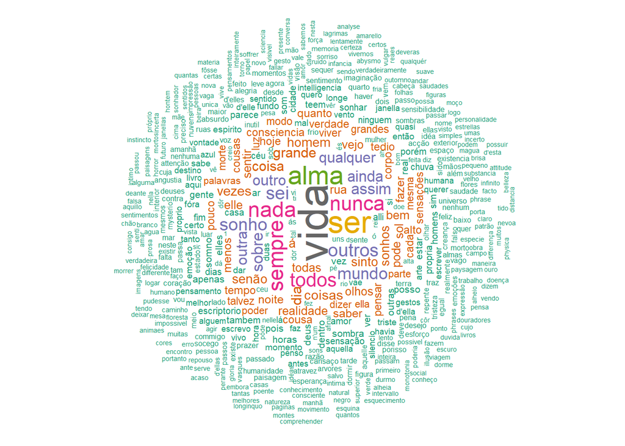

```r
# demonstração de como as frequências de palavras alteram de acordo com a preparação do corpus
set.seed(100) #para reprodução dos resultados
textplot_wordcloud(dfm_selected_unico, min_count = 6, random_order = FALSE, rotation = .25, color = RColorBrewer::brewer.pal(8, "Dark2"))
```

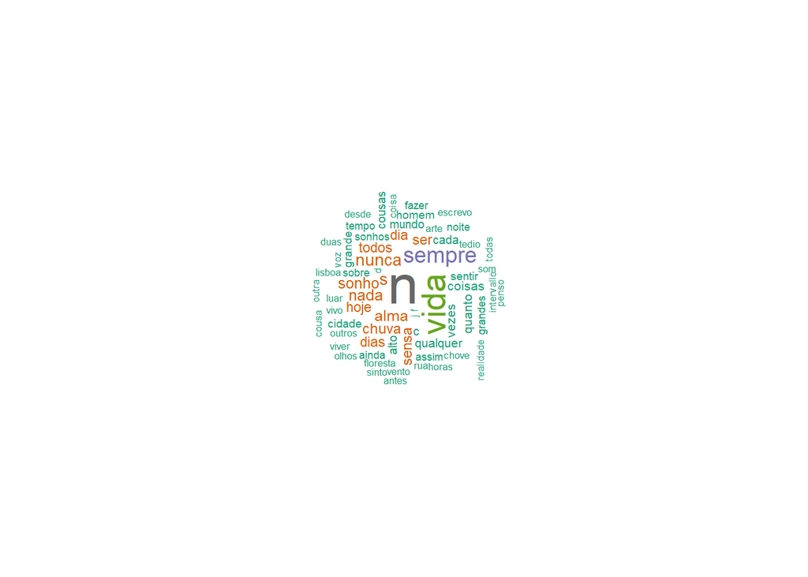

```r
set.seed(100)
textplot_wordcloud(dfm_selected_files, min_count = 6, random_order = FALSE, rotation = .25, color = RColorBrewer::brewer.pal(8, "Dark2"))
```

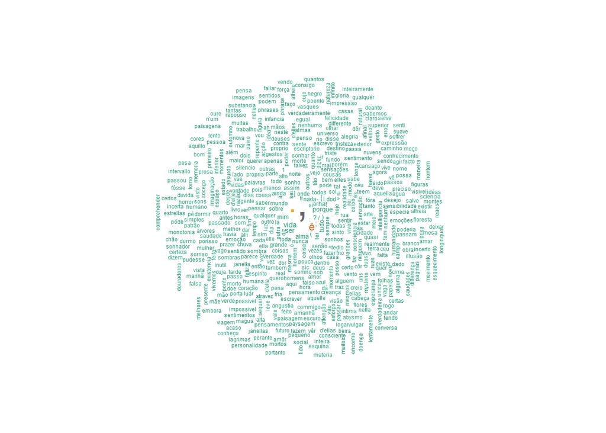

```r
set.seed(100)
textplot_wordcloud(dfm_nostop, min_count = 6, random_order = FALSE, rotation = .25, color = RColorBrewer::brewer.pal(8, "Dark2"))
```

Outra solução é utilizar a biblioteca `ggplot` e representar em um gráfico com o número de ocorrências das palavras mais frequentes.

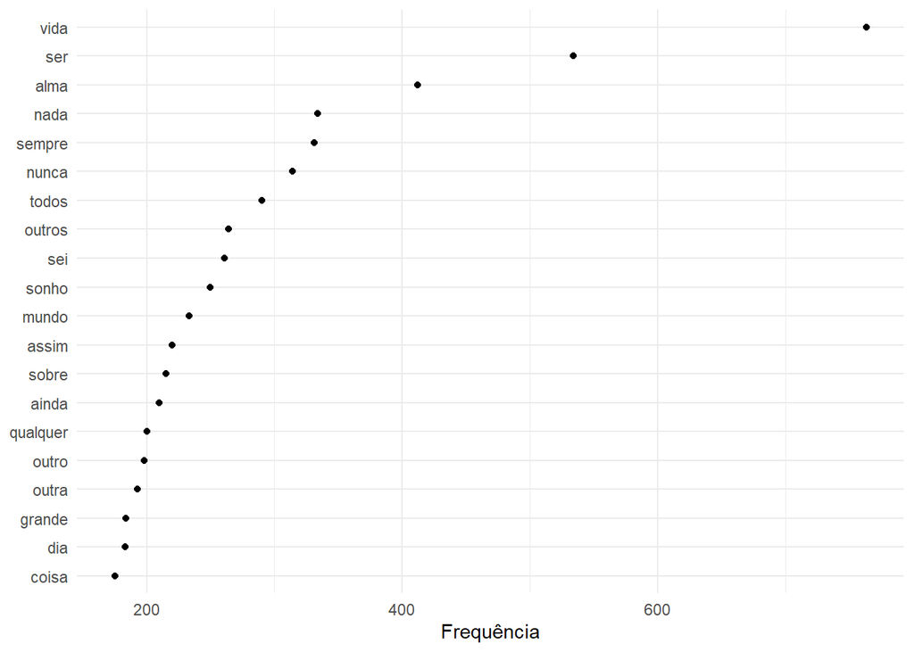

```r
dfm_selected_unico %>%
  textstat_frequency(n = 20) %>%
  ggplot(aes(x = reorder(feature, frequency), y = frequency)) +
  geom_point() +
  coord_flip() +
  labs(x = NULL, y = "Frequência") +
  theme_minimal()
```

### 2.2 Topic modeling (LDA)

Uma outra função frequentemente utilizada na PLN é a modelagem de tópicos, ou topic modeling (TM). A modelagem de tópicos aplica um modelo estatístico que procura “entender” a estrutura do corpus e identificar e agrupar palavras que de alguma forma se relacionam entre si. O TM utiliza uma técnica semi ou não supervisionada para identificação desses tópicos. Ou seja, o programa aprende a reconhecer padrões nos dados sem haver a necessidade de anotá-los previamente. O códigos abaixo demonstra a aplicação do modelo Latent Dirichlet Allocation (LDA) após.

```r
tm_nostop <- textmodel_lda(dfm_selected_files, k = 8)
terms(tm_nostop, 10)
```

```
##       topic1     topic2  topic3     topic4     topic5   topic6   topic7
##  [1,] "n"        "nada"  "chuva"    "sempre"   "n"      "sonho"  "vida"
##  [2,] "nunca"    "d"     "dias"     "vida"     "homem"  "cada"   "s"
##  [3,] "c"        "vezes" "qualquer" "ser"      "cousas" "arte"   "sensa"
##  [4,] "assim"    "luar"  "chove"    "coisas"   "j"      "sonhos" "hoje"
##  [5,] "grandes"  "mundo" "coisa"    "tedio"    "quanto" "cidade" "n"
##  [6,] "alma"     "rua"   "n"        "horas"    "tempo"  "vez"    "fazer"
##  [7,] "ainda"    "desde" "voz"      "silencio" "outros" "vivo"   "sentir"
##  [8,] "noite"    "olhos" "vejo"     "duas"     "todos"  "alto"   "sempre"
##  [9,] "floresta" "m"     "outra"    "alto"     "parte"  "viver"  "f"
## [10,] "viagem"   "l"     "calor"    "cousa"    "teem"   "novo"   "todos"
##       topic8
##  [1,] "vida"
##  [2,] "dia"
##  [3,] "sobre"
##  [4,] "antes"
##  [5,] "outro"
##  [6,] "homens"
##  [7,] "cansa"
##  [8,] "esthetica"
##  [9,] "lisboa"
## [10,] "inteira"
```

### 2.3 Semantic Network

O Feature co-occurrence matrix (FCM) é similar ao dfm, mas considerando as coocorrências, e apresenta um gráfico com as redes semânticas.

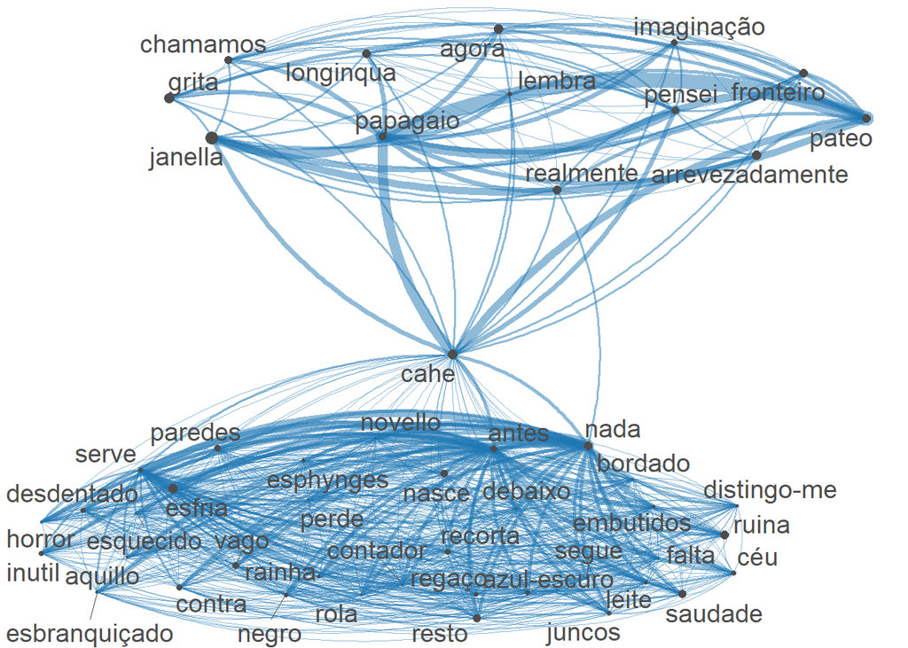

```r
#criar fcm a partir de dfm
fcm_nostop <- fcm(dfm_selected_files)
# listar as top features
feat <- names(topfeatures(fcm_nostop, 50))
#selecionar
fcm_select <- fcm_select(fcm_nostop, pattern = feat, selection = "keep")

size <- log(colSums(dfm_select(dfm_nostop, feat, selection = "keep")))

textplot_network(fcm_select, min_freq = 0.8, vertex_size = size / max(size) * 3)
```

### Dados e repositório

Os dados e códigos estão disponíveis via github https://github.com/andressarg/analise_lit_quanteda/

O código pode ser visualizado em https://rpubs.com/gomide/quanteda_LdoD

## Agradecimentos

Alguns dos códigos aqui descritos utilizaram os códigos gentilmente cedidos por Mark Alfano, utilizados em seu trabalho “Nietzsche corpus analysis”.